# Sleuth Bulk RNA-Seq and Batch Effects Tutorial

This tutorial will take you through a sample RNA-Seq analysis using performed by [kallisto](https://pachterlab.github.io/kallisto/about), using an RNA-Seq R package [Sleuth](https://pachterlab.github.io/sleuth/about). This tutorial is based on the one by the [Pachter lab](https://pachterlab.github.io/sleuth_walkthroughs/boj/analysis.html).

## Load Sleuth

Next, we need to load the Sleuth library to begin. We will also check the version:

```r
library("sleuth")
packageVersion("sleuth")
```

```
[1] ‘0.30.0’
```

## Locate sample names and describe our experimental design

First we will get a list of samples id’s as corresponds to the folders where the Kallisto outputs have been stored

```r
sample_id <- dir(file.path("~/tutorial-data/kallisto-bulk/analyses/kallisto-quantification/"))
sample_id
```

```
[1] "fastp_SRR3191542_quant"   "fastp_SRR3191543_quant"   "fastp_SRR3191544_quant"
[4] "fastp_SRR3191545_quant"   "fastp_SRR3194428_1_quant" "fastp_SRR3194429_1_quant"
[7] "fastp_SRR3194430_1_quant" "fastp_SRR3194431_1_quant"
```

We need to provide file paths to the results from kallisto:

```r
kal_dirs <- file.path("~/tutorial-data/kallisto-bulk/analyses/kallisto-quantification", sample_id)
kal_dirs
```

```
[1] "~/tutorial-data/kallisto-bulk/analyses/kallisto-quantification/fastp_SRR3191542_quant"
[2] "~/tutorial-data/kallisto-bulk/analyses/kallisto-quantification/fastp_SRR3191543_quant"
[3] "~/tutorial-data/kallisto-bulk/analyses/kallisto-quantification/fastp_SRR3191544_quant"
[4] "~/tutorial-data/kallisto-bulk/analyses/kallisto-quantification/fastp_SRR3191545_quant"
[5] "~/tutorial-data/kallisto-bulk/analyses/kallisto-quantification/fastp_SRR3194428_1_quant"
[6] "~/tutorial-data/kallisto-bulk/analyses/kallisto-quantification/fastp_SRR3194429_1_quant"
[7] "~/tutorial-data/kallisto-bulk/analyses/kallisto-quantification/fastp_SRR3194430_1_quant"
[8] "~/tutorial-data/kallisto-bulk/analyses/kallisto-quantification/fastp_SRR3194431_1_quant"
```

We an existing CSV file that provides metadata about our experiment, let’s load that:

```r
experiment_info <- read.csv("~/tutorial-data/kallisto-bulk/data/study_design/zikadesignmatrix.csv", stringsAsFactors = FALSE)
experiment_info
```

| X | sample | condition | read | fragments | Instrument | LoadDate |
| --- | --- | --- | --- | --- | --- | --- |
| 1 | SRR3191542 | mock | paired | 7927777 | Illumina MiSeq | 2016-02-26 |
| 2 | SRR3191543 | mock | paired | 7391076 | Illumina MiSeq | 2016-02-26 |
| 3 | SRR3191544 | zika | paired | 7361527 | Illumina MiSeq | 2016-02-26 |
| 4 | SRR3191545 | zika | paired | 7621347 | Illumina MiSeq | 2016-02-26 |
| 5 | SRR3194428 | mock | single | 72983243 | NextSeq 500 | 2016-02-29 |
| 6 | SRR3194429 | mock | single | 94729809 | NextSeq 500 | 2016-02-29 |
| 7 | SRR3194430 | zika | single | 71055823 | NextSeq 500 | 2016-02-29 |
| 8 | SRR3194431 | zika | single | 66528035 | NextSeq 500 | 2016-02-29 |

We will add our file paths to the table

```r
s2c <- dplyr::mutate(experiment_info, path = kal_dirs)
```

Let’s view the table we have created:

```r
s2c
```

| X | sample | condition | read | fragments | Instrument | LoadDate | path |
| --- | --- | --- | --- | --- | --- | --- | --- |
| 1 | SRR3191542 | mock | paired | 7927777 | Illumina MiSeq | 2016-02-26 | ~/tutorial-data/kallisto-bulk/analyses/kallisto-quantification/fastp_SRR3191542_quant |
| 2 | SRR3191543 | mock | paired | 7391076 | Illumina MiSeq | 2016-02-26 | ~/tutorial-data/kallisto-bulk/analyses/kallisto-quantification/fastp_SRR3191543_quant |
| 3 | SRR3191544 | zika | paired | 7361527 | Illumina MiSeq | 2016-02-26 | ~/tutorial-data/kallisto-bulk/analyses/kallisto-quantification/fastp_SRR3191544_quant |
| 4 | SRR3191545 | zika | paired | 7621347 | Illumina MiSeq | 2016-02-26 | ~/tutorial-data/kallisto-bulk/analyses/kallisto-quantification/fastp_SRR3191545_quant |
| 5 | SRR3194428 | mock | single | 72983243 | NextSeq 500 | 2016-02-29 | ~/tutorial-data/kallisto-bulk/analyses/kallisto-quantification/fastp_SRR3194428_1_quant |
| 6 | SRR3194429 | mock | single | 94729809 | NextSeq 500 | 2016-02-29 | ~/tutorial-data/kallisto-bulk/analyses/kallisto-quantification/fastp_SRR3194429_1_quant |
| 7 | SRR3194430 | zika | single | 71055823 | NextSeq 500 | 2016-02-29 | ~/tutorial-data/kallisto-bulk/analyses/kallisto-quantification/fastp_SRR3194430_1_quant |
| 8 | SRR3194431 | zika | single | 66528035 | NextSeq 500 | 2016-02-29 | ~/tutorial-data/kallisto-bulk/analyses/kallisto-quantification/fastp_SRR3194431_1_quant |

## Create the Sleuth Object

" first we need explicitly create levels in our table, marking “mock” as our control …

```r
s2c$condition <- as.factor(s2c$condition)
s2c$condition <- relevel(s2c$condition, ref = "mock")
s2c
```

| X | sample | condition | read | fragments | Instrument | LoadDate | path |
| --- | --- | --- | --- | --- | --- | --- | --- |
| 1 | SRR3191542 | mock | paired | 7927777 | Illumina MiSeq | 2016-02-26 | ~/tutorial-data/kallisto-bulk/analyses/kallisto-quantification/fastp_SRR3191542_quant |
| 2 | SRR3191543 | mock | paired | 7391076 | Illumina MiSeq | 2016-02-26 | ~/tutorial-data/kallisto-bulk/analyses/kallisto-quantification/fastp_SRR3191543_quant |
| 3 | SRR3191544 | zika | paired | 7361527 | Illumina MiSeq | 2016-02-26 | ~/tutorial-data/kallisto-bulk/analyses/kallisto-quantification/fastp_SRR3191544_quant |
| 4 | SRR3191545 | zika | paired | 7621347 | Illumina MiSeq | 2016-02-26 | ~/tutorial-data/kallisto-bulk/analyses/kallisto-quantification/fastp_SRR3191545_quant |
| 5 | SRR3194428 | mock | single | 72983243 | NextSeq 500 | 2016-02-29 | ~/tutorial-data/kallisto-bulk/analyses/kallisto-quantification/fastp_SRR3194428_1_quant |
| 6 | SRR3194429 | mock | single | 94729809 | NextSeq 500 | 2016-02-29 | ~/tutorial-data/kallisto-bulk/analyses/kallisto-quantification/fastp_SRR3194429_1_quant |
| 7 | SRR3194430 | zika | single | 71055823 | NextSeq 500 | 2016-02-29 | ~/tutorial-data/kallisto-bulk/analyses/kallisto-quantification/fastp_SRR3194430_1_quant |
| 8 | SRR3194431 | zika | single | 66528035 | NextSeq 500 | 2016-02-29 | ~/tutorial-data/kallisto-bulk/analyses/kallisto-quantification/fastp_SRR3194431_1_quant |

Next, we can use the BiomaRt library to get annotation information… our transcriptome will have ensemble gene names and we may want additional information including common gene names:

This can be a little complex so be sure to read their [documentation](https://www.bioconductor.org/packages/devel/bioc/vignettes/biomaRt/inst/doc/biomaRt.html) and this [blog post](https://nsaunders.wordpress.com/2015/04/28/some-basics-of-biomart/) is also helpful.

```r
library(biomaRt)
marts <- listMarts()
marts
```

| biomart | version |
| --- | --- |
| ENSEMBL_MART_ENSEMBL | Ensembl Genes 94 |
| ENSEMBL_MART_MOUSE | Mouse strains 94 |
| ENSEMBL_MART_SNP | Ensembl Variation 94 |
| ENSEMBL_MART_FUNCGEN | Ensembl Regulation 94 |

If you are not working with these Ensembl data bases you may want to check out documentation on [using BiomaRts other than Ensembl](https://bioconductor.org/packages/release/bioc/vignettes/biomaRt/inst/doc/biomaRt.html#using-a-biomart-other-than-ensembl).Since this is human data we can use `ENSEMBL_MART_ENSEMBL`.

```r
ensembl_mart <- useMart("ENSEMBL_MART_ENSEMBL" )
listDatasets(ensembl_mart)
```

| dataset | description | version |
| --- | --- | --- |
| acalliptera_gene_ensembl | Eastern happy genes (fAstCal1.2) | fAstCal1.2 |
| acarolinensis_gene_ensembl | Anole lizard genes (AnoCar2.0) | AnoCar2.0 |
| acitrinellus_gene_ensembl | Midas cichlid genes (Midas_v5) | Midas_v5 |
| amelanoleuca_gene_ensembl | Panda genes (ailMel1) | ailMel1 |
| amexicanus_gene_ensembl | Cave fish genes (Astyanax_mexicanus-2.0) | Astyanax_mexicanus-2.0 |
| anancymaae_gene_ensembl | Ma's night monkey genes (Anan_2.0) | Anan_2.0 |
| aocellaris_gene_ensembl | Clown anemonefish genes (AmpOce1.0) | AmpOce1.0 |
| apercula_gene_ensembl | Orange clownfish genes (Nemo_v1) | Nemo_v1 |
| aplatyrhynchos_gene_ensembl | Duck genes (BGI_duck_1.0) | BGI_duck_1.0 |
| apolyacanthus_gene_ensembl | Spiny chromis genes (ASM210954v1) | ASM210954v1 |

[output cut: 128 more lines]

After a little looking, its the `hsapiens_gene_ensembl` dataset that we need. Finally, we need to update our `ensembl_mart` to be more specific.

```r
ensembl_mart <- useMart("ENSEMBL_MART_ENSEMBL", dataset = "hsapiens_gene_ensembl")
```

Now we want to get specific attributes from the list of genes we can import from biomart

```r
listAttributes(ensembl_mart)
```

| name | description | page |
| --- | --- | --- |
| ensembl_gene_id | Gene stable ID | feature_page |
| ensembl_gene_id_version | Gene stable ID version | feature_page |
| ensembl_transcript_id | Transcript stable ID | feature_page |
| ensembl_transcript_id_version | Transcript stable ID version | feature_page |
| ensembl_peptide_id | Protein stable ID | feature_page |
| ensembl_peptide_id_version | Protein stable ID version | feature_page |
| ensembl_exon_id | Exon stable ID | feature_page |
| description | Gene description | feature_page |
| chromosome_name | Chromosome/scaffold name | feature_page |
| start_position | Gene start (bp) | feature_page |

[output cut: 990 more lines]

We can choose whichever of these we’d like to use. Let’s get transcript ids, gene ids, a description, and gene names. Notice, there are many things you may want to come back for. We must get the transcript id because these are the names of the transcripts that were used in our Kallisto quantification.

```r
t2g <- getBM(attributes = c("ensembl_transcript_id",
                            "ensembl_gene_id",
                            "description",
                            "external_gene_name"),
             mart = ensembl_mart)
```

We need to make sure the `ensembl_transcript_id` column is named `target_id`

```r
ttg <- dplyr::rename(t2g, target_id= ensembl_transcript_id, ens_gene = ensembl_gene_id, ext_gene = external_gene_name)
```

Now we need to tell Sleuth both about the Kallisto results and the gene names (and gene descriptions/metadata) we obtained from biomaRt. The `sleuth_prep` function does this. (~5 minutes)

```r
so <- sleuth_prep(s2c,
                  full_model = ~condition,
                  target_mapping = ttg,
                  read_bootstrap_tpm=TRUE,
                  extra_bootstrap_summary = TRUE)
```

```
It appears that you are running Sleuth from within Rstudio.
Because of concerns with forking processes from a GUI, 'num_cores' is being set to 1.
If you wish to take advantage of multiple cores, please consider running sleuth from the command line.reading in kallisto results
dropping unused factor levels
........
intersection between target_id from kallisto runs and the target_mapping is empty. attempted to fix problem by removing .N from target_id, then merging back into target_mapping. please check obj$target_mapping to ensure this new mapping is correct.normalizing est_counts
81105 targets passed the filter
normalizing tpm
merging in metadata
summarizing bootstraps
........
```

## Differential expression analysis

We will also load some additional libraries we will need for plotting

```r
library(cowplot)
library(gridExtra)
```

Next, we should check to see if our samples (and replicates) cluster on a PCA (as should expect) or if there are outliers:

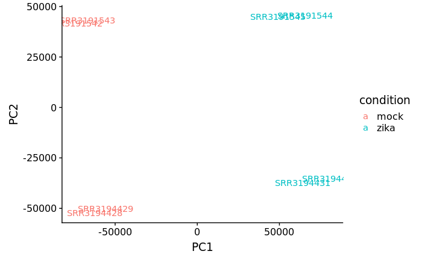

```r
plot_pca(so, color_by = 'condition', text_labels = TRUE)
```

We successfully replicate the figure in the [paper](https://journals.plos.org/plosone/article?id=10.1371/journal.pone.0175744) this data were taken from. Uninfected (mock) cluster on the left of the PC1 axis, and zika-infected are on the right. Along the second component, we can see that there is variation due to the sequencing platform. We can redraw the plot to demonstrate this:

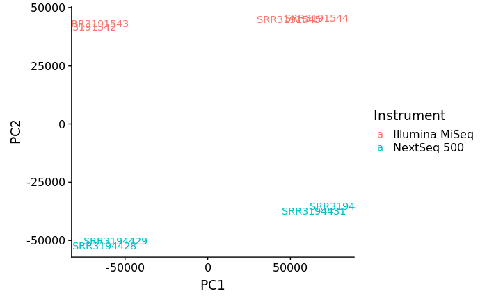

```r
plot_pca(so, color_by = 'Instrument', text_labels = TRUE)
```

```
pc_input being set to first principal component since was not specified.
```

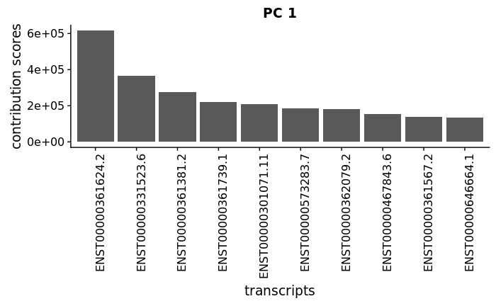

```r
plot_loadings(so,pc_count = 10) + theme(axis.text.x = element_text(angle = 90, hjust = 1))
```

We will come back to batch effects later.

## Tests and visualizations.

Now we need to run a few functions that will test for differential expression (abundance).To identify genes differential between two conditions two models must be fit by sleuth.

We need two (linear) models to compare:

- Full model: This is a model of the abundance estimates taking into account our experimental conditions

```r
so <- sleuth_fit(so, ~condition, 'full')
```

```
fitting measurement error models
shrinkage estimation
8 NA values were found during variance shrinkage estimation due to mean observation values outside of the range used for the LOESS fit.
The LOESS fit will be repeated using exact computation of the fitted surface to extrapolate the missing values.
These are the target ids with NA values: ENST00000307161.5, ENST00000372898.6, ENST00000415786.1, ENST00000423862.5, ENST00000524292.5, ENST00000542041.1, ENST00000570801.1, ENST00000577857.5
computing variance of betas
```

Occasionally, you will get some warning about genes/transcripts that were dropped from analysis. These don’t have to be a problem, but you may want to make sure your favorite has not been lost.

- Reduced model: This model (null hypothesis) assumes that abundances are equal between the conditions

```r
so <- sleuth_fit(so, ~1, 'reduced')
```

```
fitting measurement error models
shrinkage estimation
8 NA values were found during variance shrinkage estimation due to mean observation values outside of the range used for the LOESS fit.
The LOESS fit will be repeated using exact computation of the fitted surface to extrapolate the missing values.
These are the target ids with NA values: ENST00000307161.5, ENST00000372898.6, ENST00000415786.1, ENST00000423862.5, ENST00000524292.5, ENST00000542041.1, ENST00000570801.1, ENST00000577857.5
computing variance of betas
```

```r
so <- sleuth_lrt(so, 'reduced', 'full')
```

Now we can get the results of this analysis

```r
full_results <- sleuth_results(so, 'reduced:full', 'lrt',
                               show_all = FALSE)
full_results_signifigant <- dplyr::filter(full_results, qval <= 0.05)
head(full_results_signifigant, 20)
```

|  | ens_gene | description | ext_gene | target_id | pval | qval | test_stat | rss | degrees_free | mean_obs | var_obs | tech_var | sigma_sq | smooth_sigma_sq | final_sigma_sq |
| --- | --- | --- | --- | --- | --- | --- | --- | --- | --- | --- | --- | --- | --- | --- | --- |
| 1 | ENSG00000130766 | sestrin 2 [Source:HGNC Symbol;Acc:HGNC:20746] | SESN2 | ENST00000253063.3 | 1.777452e-09 | 2.972865e-05 | 36.20356 | 3.857878 | 1 | 6.542592 | 0.5511254 | 0.001611916 | 0.5495135 | 0.02362979 | 0.5495135 |
| 2 | ENSG00000171848 | ribonucleotide reductase regulatory subunit M2 [Source:HGNC Symbol;Acc:HGNC:10452] | RRM2 | ENST00000304567.9 | 2.199271e-09 | 2.972865e-05 | 35.78863 | 7.680264 | 1 | 6.304787 | 1.0971806 | 0.014076611 | 1.0831040 | 0.02611150 | 1.0831040 |
| 3 | ENSG00000168209 | DNA damage inducible transcript 4 [Source:HGNC Symbol;Acc:HGNC:24944] | DDIT4 | ENST00000307365.3 | 3.987219e-10 | 2.972865e-05 | 39.11911 | 3.459832 | 1 | 7.328071 | 0.4942617 | 0.001652028 | 0.4926097 | 0.02035920 | 0.4926097 |
| 4 | ENSG00000168003 | solute carrier family 3 member 2 [Source:HGNC Symbol;Acc:HGNC:11026] | SLC3A2 | ENST00000338663.11 | 2.002104e-09 | 2.972865e-05 | 35.97164 | 5.199625 | 1 | 7.798067 | 0.7428036 | 0.003434384 | 0.7393692 | 0.02148000 | 0.7393692 |
| 5 | ENSG00000075290 | Wnt family member 8B [Source:HGNC Symbol;Acc:HGNC:12789] | WNT8B | ENST00000343737.5 | 1.384739e-09 | 2.972865e-05 | 36.69020 | 4.575765 | 1 | 6.624816 | 0.6536808 | 0.002787981 | 0.6508928 | 0.02295537 | 0.6508928 |
| 6 | ENSG00000285069 | sestrin 2 [Source:HGNC Symbol;Acc:HGNC:20746] | SESN2 | ENST00000645231.1 | 1.777452e-09 | 2.972865e-05 | 36.20356 | 3.857878 | 1 | 6.542592 | 0.5511254 | 0.001611916 | 0.5495135 | 0.02362979 | 0.5495135 |
| 7 | ENSG00000076003 | minichromosome maintenance complex component 6 [Source:HGNC Symbol;Acc:HGNC:6949] | MCM6 | ENST00000264156.2 | 3.066366e-09 | 3.108720e-05 | 35.14125 | 3.800920 | 1 | 6.807385 | 0.5429885 | 0.002498801 | 0.5404897 | 0.02175899 | 0.5404897 |
| 8 | ENSG00000073111 | minichromosome maintenance complex component 2 [Source:HGNC Symbol;Acc:HGNC:6944] | MCM2 | ENST00000265056.11 | 2.828599e-09 | 3.108720e-05 | 35.29843 | 2.567784 | 1 | 7.260788 | 0.3668262 | 0.003246254 | 0.3635800 | 0.02038355 | 0.3635800 |
| 9 | ENSG00000130254 | scaffold attachment factor B2 [Source:HGNC Symbol;Acc:HGNC:21605] | SAFB2 | ENST00000252542.8 | 4.529707e-09 | 4.082021e-05 | 34.38166 | 2.106534 | 1 | 7.542593 | 0.3009334 | 0.001465449 | 0.2994680 | 0.02058559 | 0.2994680 |
| 10 | ENSG00000070669 | asparagine synthetase (glutamine-hydrolyzing) [Source:HGNC Symbol;Acc:HGNC:753] | ASNS | ENST00000394308.7 | 5.477144e-09 | 4.442238e-05 | 34.01206 | 3.499862 | 1 | 7.854916 | 0.4999803 | 0.003362729 | 0.4966175 | 0.02177716 | 0.4966175 |

[output cut: 10 more lines]

We can easily plot the result from individual genes

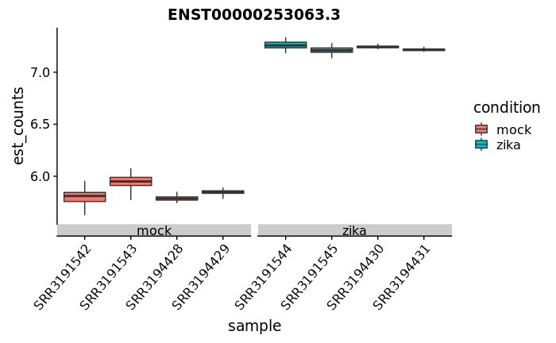

```r
plot_bootstrap(so, "ENST00000253063.3", units = "est_counts", color_by = "condition")
```

Let’s add Wald test

```r
wald_test <- colnames(design_matrix(so))[2]
so <- sleuth_wt(so, wald_test)
```

And start a Shiny Browser to view plots interactively

```r
sleuth_live(so)
```

[output not shown]

[output not shown]

## Examining batch effects

As we saw in the PCA plot, there was a difference in sample, which we can attribute to the differences in instrument. Here is the PCA plots again:

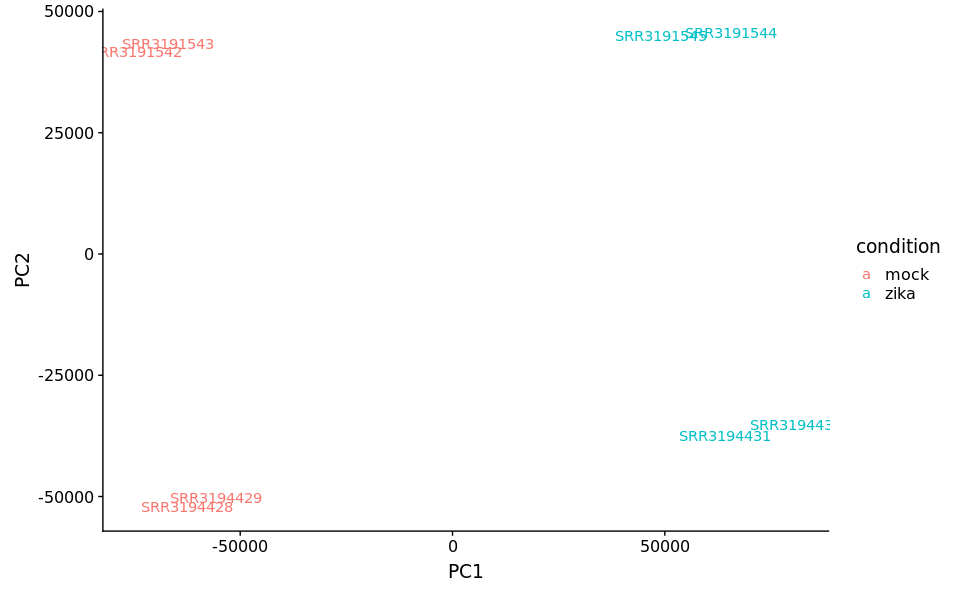

```r
plot_pca(so, color_by = 'condition', text_labels = TRUE)
```

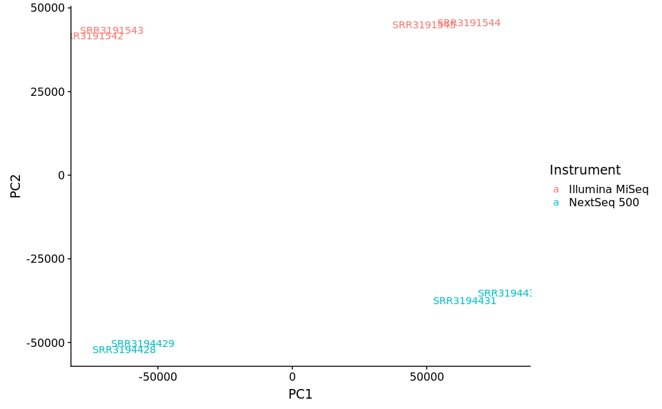

```r
plot_pca(so, color_by = 'Instrument', text_labels = TRUE)
```

We can make a new linear model and examine how our estimates of abundance would be explained accounting for Instrument type

```r
so <- sleuth_fit(so, ~Instrument, 'Instrument')
```

```
fitting measurement error models
shrinkage estimation
67 NA values were found during variance shrinkage estimation due to mean observation values outside of the range used for the LOESS fit.
The LOESS fit will be repeated using exact computation of the fitted surface to extrapolate the missing values.
These are the target ids with NA values: ENST00000230732.5, ENST00000307161.5, ENST00000340697.4, ENST00000371970.2, ENST00000372898.6, ENST00000373685.1, ENST00000382119.1, ENST00000399417.3, ENST00000414620.1, ENST00000415786.1, ENST00000417985.1, ENST00000420113.1, ENST00000422100.1, ENST00000423…
computing variance of betas
```

And we will perform a log-ratio test with our existing reduced model here as well:

```r
so <- sleuth_lrt(so,'reduced', 'Instrument')
```

Now we can pinpoint which genes are most affected by this batch effect:

```r
sleuth_table_instrument <- sleuth_results(so, 'reduced:Instrument','lrt', show_all = FALSE)
sleuth_significant_instrument <- dplyr::filter(sleuth_table_instrument, qval <= 0.05)
head(sleuth_significant_instrument, 20)
```

|  | ens_gene | description | ext_gene | target_id | pval | qval | test_stat | rss | degrees_free | mean_obs | var_obs | tech_var | sigma_sq | smooth_sigma_sq | final_sigma_sq |
| --- | --- | --- | --- | --- | --- | --- | --- | --- | --- | --- | --- | --- | --- | --- | --- |
| 1 | ENSG00000124614 | ribosomal protein S10 [Source:HGNC Symbol;Acc:HGNC:10383] | RPS10 | ENST00000326199.12 | 6.590610e-10 | 2.672657e-05 | 38.13823 | 158.300755 | 1 | 3.754900 | 22.6143936 | 0.0003774226 | 22.6140162 | 0.43662082 | 22.6140162 |
| 2 | ENSG00000144713 | ribosomal protein L32 [Source:HGNC Symbol;Acc:HGNC:10336] | RPL32 | ENST00000452606.2 | 4.097000e-10 | 2.672657e-05 | 39.06608 | 27.720243 | 1 | 5.760766 | 3.9600347 | 0.0154523896 | 3.9445823 | 0.03592881 | 3.9445823 |
| 3 | ENSG00000161016 | ribosomal protein L8 [Source:HGNC Symbol;Acc:HGNC:10368] | RPL8 | ENST00000262584.7 | 1.948014e-09 | 5.266456e-05 | 36.02501 | 26.085506 | 1 | 6.963763 | 3.7265008 | 0.0676058375 | 3.6588950 | 0.02103936 | 3.6588950 |
| 4 | ENSG00000070756 | poly(A) binding protein cytoplasmic 1 [Source:HGNC Symbol;Acc:HGNC:8554] | PABPC1 | ENST00000318607.9 | 3.422294e-09 | 6.939129e-05 | 34.92741 | 7.928130 | 1 | 6.841200 | 1.1325900 | 0.0115432440 | 1.1210467 | 0.02158038 | 1.1210467 |
| 5 | ENSG00000122026 | ribosomal protein L21 [Source:HGNC Symbol;Acc:HGNC:10313] | RPL21 | ENST00000311549.10 | 7.557268e-09 | 1.021554e-04 | 33.38583 | 3.707884 | 1 | 7.806479 | 0.5296977 | 0.0026992662 | 0.5269984 | 0.02152163 | 0.5269984 |
| 6 | ENSG00000143933 | calmodulin 2 [Source:HGNC Symbol;Acc:HGNC:1445] | CALM2 | ENST00000432899.5 | 6.703420e-09 | 1.021554e-04 | 33.61902 | 134.064928 | 1 | 3.400133 | 19.1521325 | 0.0015671269 | 19.1505654 | 0.65922387 | 19.1505654 |
| 7 | ENSG00000205542 | thymosin beta 4 X-linked [Source:HGNC Symbol;Acc:HGNC:11881] | TMSB4X | ENST00000380633.1 | 1.069275e-08 | 1.238908e-04 | 32.71105 | 132.040875 | 1 | 3.363440 | 18.8629821 | 0.0006213926 | 18.8623607 | 0.68511976 | 18.8623607 |
| 8 | ENSG00000008988 | ribosomal protein S20 [Source:HGNC Symbol;Acc:HGNC:10405] | RPS20 | ENST00000520627.1 | 1.859058e-08 | 1.301488e-04 | 31.63646 | 122.753910 | 1 | 3.223580 | 17.5362729 | 0.0009738688 | 17.5352990 | 0.79073935 | 17.5352990 |
| 9 | ENSG00000167996 | ferritin heavy chain 1 [Source:HGNC Symbol;Acc:HGNC:3976] | FTH1 | ENST00000526640.5 | 2.246573e-08 | 1.301488e-04 | 31.26883 | 120.525104 | 1 | 3.188203 | 17.2178720 | 0.0018145141 | 17.2160575 | 0.81887404 | 17.2160575 |
| 10 | ENSG00000166441 | ribosomal protein L27a [Source:HGNC Symbol;Acc:HGNC:10329] | RPL27A | ENST00000531978.5 | 2.140935e-08 | 1.301488e-04 | 31.36234 | 7.987144 | 1 | 5.617928 | 1.1410206 | 0.0119761500 | 1.1290444 | 0.03999436 | 1.1290444 |

[output cut: 10 more lines]

We can now create a model that accounts for differences by condition as well as instrument:

```r
so <- sleuth_fit(so, ~condition + Instrument, 'full')
```

```
fitting measurement error models
shrinkage estimation
70 NA values were found during variance shrinkage estimation due to mean observation values outside of the range used for the LOESS fit.
The LOESS fit will be repeated using exact computation of the fitted surface to extrapolate the missing values.
These are the target ids with NA values: ENST00000230732.5, ENST00000307161.5, ENST00000340697.4, ENST00000371970.2, ENST00000372898.6, ENST00000373685.1, ENST00000382119.1, ENST00000399417.3, ENST00000414620.1, ENST00000415786.1, ENST00000417985.1, ENST00000420113.1, ENST00000422100.1, ENST00000423…
computing variance of betas
```

Now we will compare the instrument model with the ‘full’ model that accounts for both

```r
so <- sleuth_lrt(so, 'Instrument', 'full')
sleuth_table_full <- sleuth_results(so, 'Instrument:full', 'lrt', show_all = FALSE)
sleuth_significant_instrument_condition <- dplyr::filter(sleuth_table_full, qval <= 0.05)
head(sleuth_significant_instrument_condition, 20)
```

|  | ens_gene | description | ext_gene | target_id | pval | qval | test_stat | rss | degrees_free | mean_obs | var_obs | tech_var | sigma_sq | smooth_sigma_sq | final_sigma_sq |
| --- | --- | --- | --- | --- | --- | --- | --- | --- | --- | --- | --- | --- | --- | --- | --- |
| 1 | ENSG00000168209 | DNA damage inducible transcript 4 [Source:HGNC Symbol;Acc:HGNC:24944] | DDIT4 | ENST00000307365.3 | 5.585273e-12 | 1.566170e-07 | 47.46998 | 3.459605 | 1 | 7.328071 | 0.4942617 | 0.0016520282 | 0.5749489 | 0.01173686 | 0.5749489 |
| 2 | ENSG00000149428 | hypoxia up-regulated 1 [Source:HGNC Symbol;Acc:HGNC:16931] | HYOU1 | ENST00000617285.4 | 5.793120e-12 | 1.566170e-07 | 47.39836 | 1.748231 | 1 | 7.998039 | 0.2538933 | 0.0004337567 | 0.2909381 | 0.01179863 | 0.2909381 |
| 3 | ENSG00000280682 | hypoxia up-regulated 1 [Source:HGNC Symbol;Acc:HGNC:16931] | HYOU1 | ENST00000630669.2 | 5.793120e-12 | 1.566170e-07 | 47.39836 | 1.748231 | 1 | 7.998039 | 0.2538933 | 0.0004337567 | 0.2909381 | 0.01179863 | 0.2909381 |
| 4 | ENSG00000128590 | DnaJ heat shock protein family (Hsp40) member B9 [Source:HGNC Symbol;Acc:HGNC:6968] | DNAJB9 | ENST00000249356.3 | 1.326405e-11 | 2.386436e-07 | 45.77508 | 3.178862 | 1 | 7.142737 | 0.4870862 | 0.0017744261 | 0.5280360 | 0.01226629 | 0.5280360 |
| 5 | ENSG00000151012 | solute carrier family 7 member 11 [Source:HGNC Symbol;Acc:HGNC:11059] | SLC7A11 | ENST00000280612.9 | 1.471202e-11 | 2.386436e-07 | 45.57213 | 5.790067 | 1 | 7.006361 | 0.8641937 | 0.0022802443 | 0.9627310 | 0.01282454 | 0.9627310 |
| 6 | ENSG00000090861 | alanyl-tRNA synthetase [Source:HGNC Symbol;Acc:HGNC:20] | AARS | ENST00000261772.12 | 2.024014e-11 | 2.655031e-07 | 44.94737 | 1.402660 | 1 | 7.958210 | 0.2018723 | 0.0006008635 | 0.2331758 | 0.01170930 | 0.2331758 |
| 7 | ENSG00000168003 | solute carrier family 3 member 2 [Source:HGNC Symbol;Acc:HGNC:11026] | SLC3A2 | ENST00000338663.11 | 2.291500e-11 | 2.655031e-07 | 44.70433 | 5.160704 | 1 | 7.798067 | 0.7428036 | 0.0034343842 | 0.8566829 | 0.01146244 | 0.8566829 |
| 8 | ENSG00000188229 | tubulin beta 4B class IVb [Source:HGNC Symbol;Acc:HGNC:20771] | TUBB4B | ENST00000340384.4 | 6.762284e-11 | 6.182791e-07 | 42.58655 | 1.391277 | 1 | 8.050669 | 0.1995160 | 0.0006997158 | 0.2311799 | 0.01193431 | 0.2311799 |
| 9 | ENSG00000134884 | arginine and glutamate rich 1 [Source:HGNC Symbol;Acc:HGNC:25482] | ARGLU1 | ENST00000472226.2 | 6.860874e-11 | 6.182791e-07 | 42.55824 | 1.799389 | 1 | 8.672830 | 0.2787664 | 0.0003817005 | 0.2995165 | 0.01531658 | 0.2995165 |
| 10 | ENSG00000075290 | Wnt family member 8B [Source:HGNC Symbol;Acc:HGNC:12789] | WNT8B | ENST00000343737.5 | 8.107144e-11 | 6.185924e-07 | 42.23179 | 4.565727 | 1 | 6.624816 | 0.6536808 | 0.0027879812 | 0.7581666 | 0.01528063 | 0.7581666 |

[output cut: 10 more lines]

There are some similarities and differences but let’s look more systematically…

```r
tmp <- dplyr::inner_join(
  dplyr::mutate(
    dplyr::select(full_results_signifigant, target_id, qval_condition = qval),
    rank_condition = 1:length(qval_condition)),
  dplyr::mutate(
    dplyr::select(sleuth_significant_instrument_condition, target_id, qval_account_for_batch = qval),
    rank_account_for_batch = 1:length(qval_account_for_batch))
  ,
  by = 'target_id')
```

We’ll get the relative difference between the ranked lists of values

```r
tmp <- dplyr::mutate(tmp,
  relative_difference = abs(rank_account_for_batch - rank_condition) / (rank_account_for_batch + rank_condition))
```

We can then join few of these

```r
top_different <- dplyr::arrange(head(tmp, 100), desc(relative_difference))
p <- lapply(top_different$target_id[1:4],
  function(x) {
    plot_bootstrap(so, x, color_by = 'condition')
  })
```

And then plot

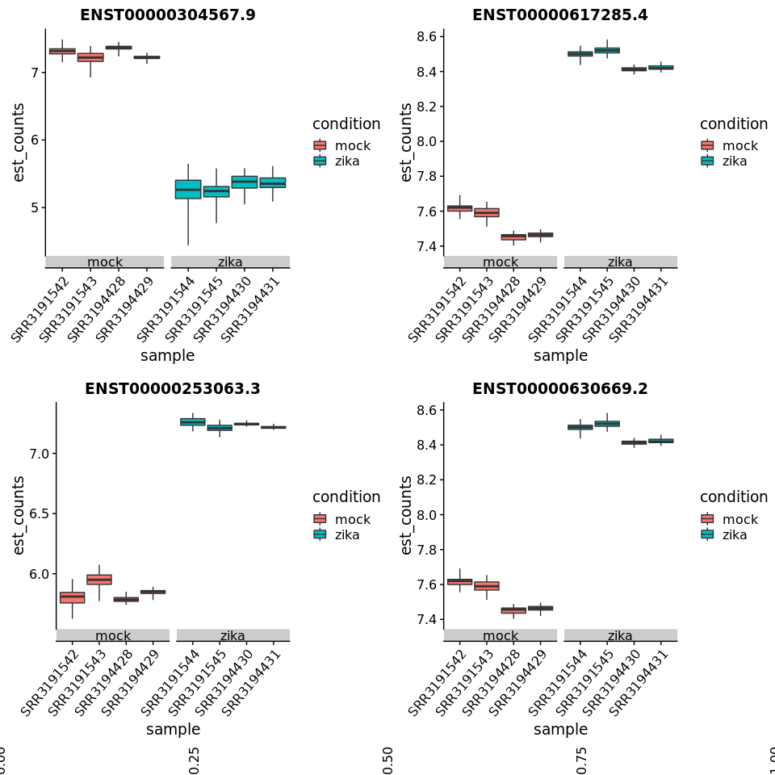

```r
plot_grid(plotlist = p)+ theme(axis.text.x = element_text(angle = 90, hjust = 1))
```

### Comparing effect sizes

We can also get a gene by gene look at how these batch effects impacted each gene

```r
full_model <- extract_model(so, 'full')
condition_model <- extract_model(so, 'condition')
```

```r
effect_sizes <- dplyr::inner_join(
  dplyr::select(dplyr::filter(full_model, grepl('condition', term)),
    target_id, full_estimate = estimate),
  dplyr::select(dplyr::filter(condition_model, grepl('condition', term)),
    target_id, condition_estimate = estimate),
  by = 'target_id'
  )
dplyr::inner_join(
  dplyr::select(top_different[1:100, ], target_id),
  effect_sizes,
  by = 'target_id')
```

| target_id | full_estimate | condition_estimate |
| --- | --- | --- |
| ENST00000304567.9 | -1.9564012 | -1.9564012 |
| ENST00000617285.4 | 0.9345028 | 0.9345028 |
| ENST00000253063.3 | 1.3858149 | 1.3858149 |
| ENST00000630669.2 | 0.9345028 | 0.9345028 |
| ENST00000375366.3 | -1.2474011 | -1.2474011 |
| ENST00000303004.4 | 2.1075906 | 2.1075906 |
| ENST00000409160.7 | -1.4061699 | -1.4061699 |
| ENST00000295470.9 | -7.7986800 | -7.7986800 |
| ENST00000323274.14 | -0.9669561 | -0.9669561 |
| ENST00000433529.6 | -8.2102193 | -8.2102193 |

[output cut: 90 more lines]

In this case, the batch effects are minimal.